# The forecaster’s toolbox

## A tidy forecasting workflow

```r
gdppc <- global_economy %>%
  mutate(GDP_per_capita = GDP / Population)
gdppc
```

```
## # A tsibble: 15,150 x 10 [1Y]
## # Key:       Country [263]
##    Country     Code   Year         GDP Growth   CPI Imports Exports Population
##    <fct>       <fct> <dbl>       <dbl>  <dbl> <dbl>   <dbl>   <dbl>      <dbl>
##  1 Afghanistan AFG    1960  537777811.     NA    NA    7.02    4.13    8996351
##  2 Afghanistan AFG    1961  548888896.     NA    NA    8.10    4.45    9166764
##  3 Afghanistan AFG    1962  546666678.     NA    NA    9.35    4.88    9345868
##  4 Afghanistan AFG    1963  751111191.     NA    NA   16.9     9.17    9533954
##  5 Afghanistan AFG    1964  800000044.     NA    NA   18.1     8.89    9731361
##  6 Afghanistan AFG    1965 1006666638.     NA    NA   21.4    11.3     9938414
##  7 Afghanistan AFG    1966 1399999967.     NA    NA   18.6     8.57   10152331
##  8 Afghanistan AFG    1967 1673333418.     NA    NA   14.2     6.77   10372630
##  9 Afghanistan AFG    1968 1373333367.     NA    NA   15.2     8.90   10604346
## 10 Afghanistan AFG    1969 1408888922.     NA    NA   15.0    10.1    10854428
## # ... with 15,140 more rows, and 1 more variable: GDP_per_capita <dbl>
```

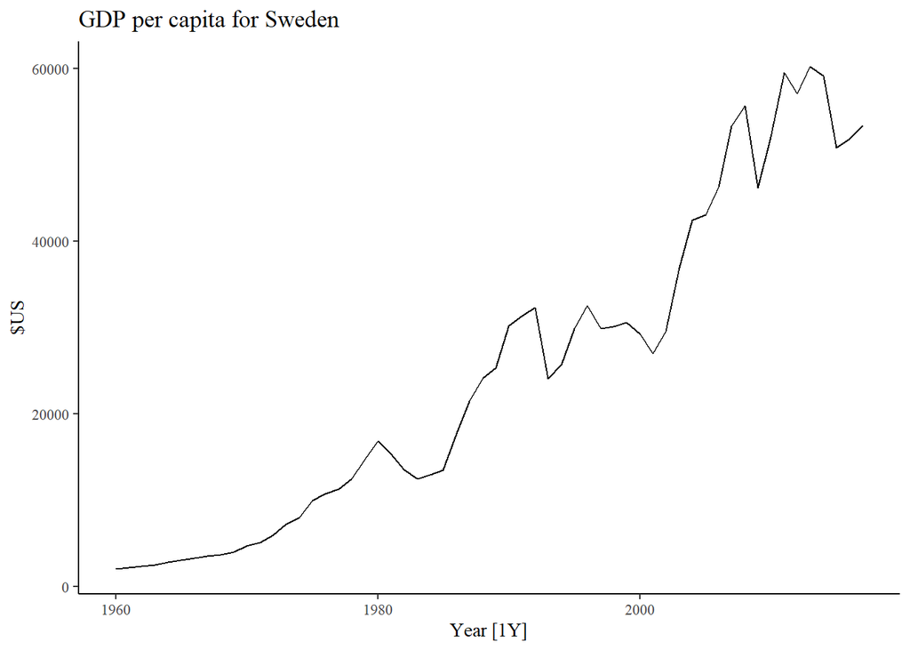

```r
gdppc %>%
  filter(Country == "Sweden") %>%
  autoplot(GDP_per_capita) +
  labs(y = "$US", title = "GDP per capita for Sweden")
```

```r
fit <- gdppc %>%
  model(trend_model = TSLM(GDP_per_capita ~ trend()))
fit %>% forecast(h = "3 years")
```

```
## # A fable: 789 x 5 [1Y]
## # Key:     Country, .model [263]
##    Country        .model       Year   GDP_per_capita  .mean
##    <fct>          <chr>       <dbl>           <dist>  <dbl>
##  1 Afghanistan    trend_model  2018     N(526, 9653)   526.
##  2 Afghanistan    trend_model  2019     N(534, 9689)   534.
##  3 Afghanistan    trend_model  2020     N(542, 9727)   542.
##  4 Albania        trend_model  2018  N(4716, 476419)  4716.
##  5 Albania        trend_model  2019  N(4867, 481086)  4867.
##  6 Albania        trend_model  2020  N(5018, 486012)  5018.
##  7 Algeria        trend_model  2018  N(4410, 643094)  4410.
##  8 Algeria        trend_model  2019  N(4489, 645311)  4489.
##  9 Algeria        trend_model  2020  N(4568, 647602)  4568.
## 10 American Samoa trend_model  2018 N(12491, 652926) 12491.
## # ... with 779 more rows
```

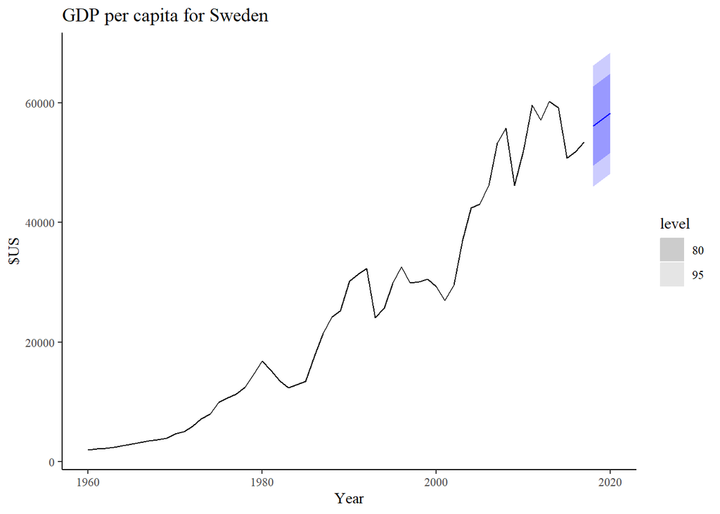

```r
fit %>%
  filter(Country == "Sweden") %>%
  forecast(h = "3 years") %>%
  autoplot(gdppc) +
  labs(y = "$US", title = "GDP per capita for Sweden")
```

## Some simple forecasting methods

```r
bricks <- aus_production %>%
  filter_index("1970 Q1" ~ "2004 Q4")
```

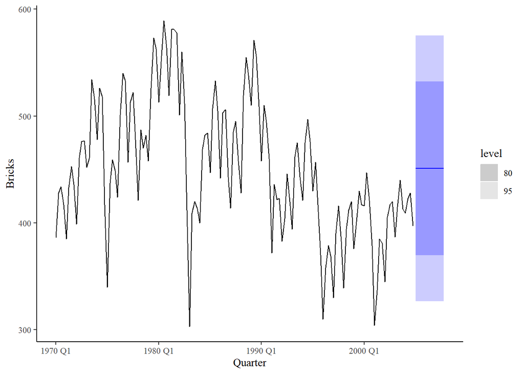

```r
bricks %>% model(mean = MEAN(Bricks)) %>% forecast(h = "3 years") %>% autoplot(bricks)
```

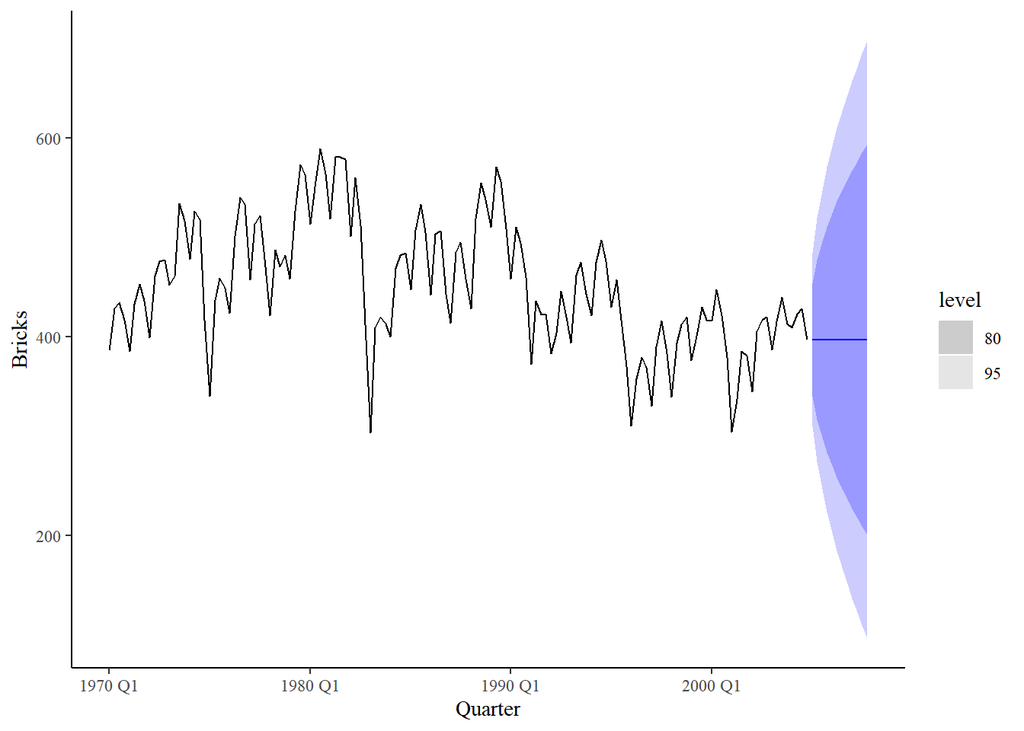

```r
bricks %>% model(NAIVE(Bricks)) %>% forecast(h = "3 years") %>% autoplot(bricks)
```

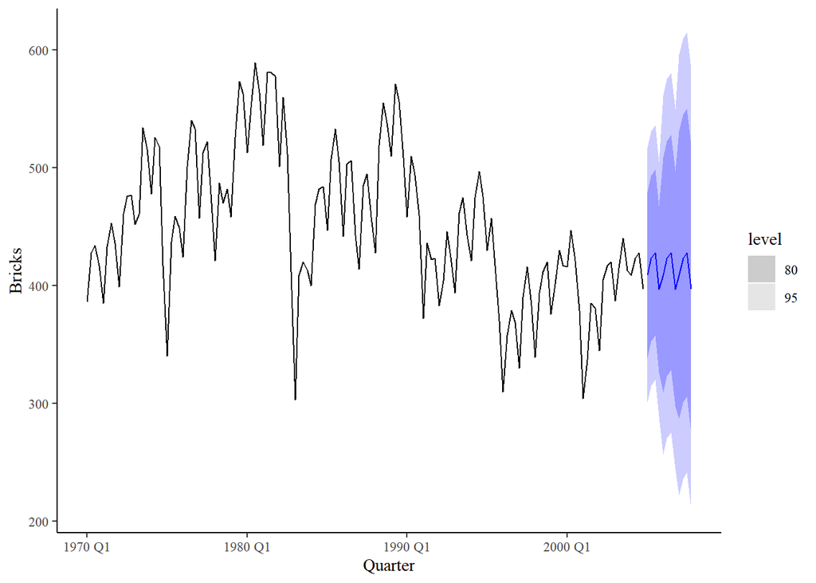

```r
bricks %>% model(SNAIVE(Bricks ~ lag("year"))) %>% forecast(h = "3 years") %>% autoplot(bricks)
```

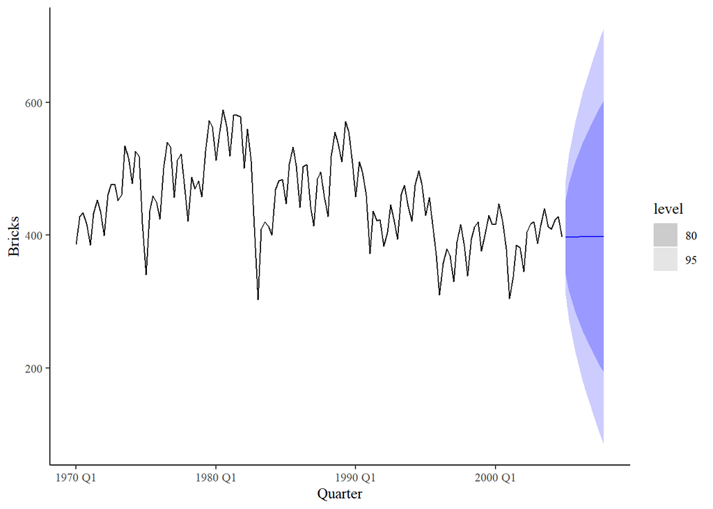

```r
bricks %>% model(RW(Bricks ~ drift())) %>% forecast(h = "3 years") %>% autoplot(bricks)
```

```
## Plot variable not specified, automatically selected `.vars = Beer`
```

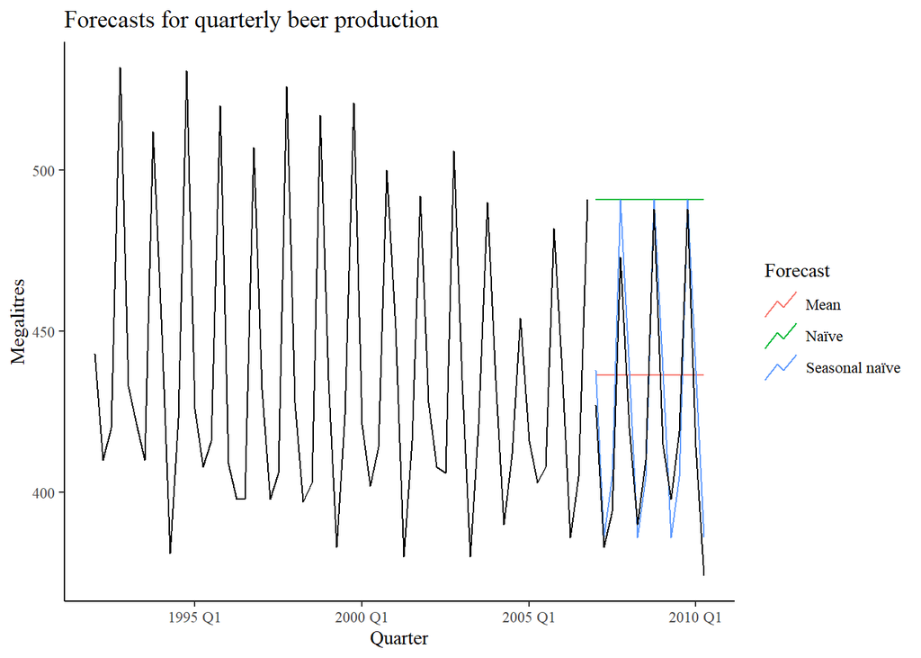

```r
# Set training data from 1992 to 2006
train <- aus_production %>%
  filter_index("1992 Q1" ~ "2006 Q4")
# Fit the models
beer_fit <- train %>%
  model(
    Mean = MEAN(Beer),
    `Naïve` = NAIVE(Beer),
    `Seasonal naïve` = SNAIVE(Beer)
  )
# Generate forecasts for 14 quarters
beer_fc <- beer_fit %>% forecast(h = 14)
# Plot forecasts against actual values
beer_fc %>%
  autoplot(train, level = NULL) +
  autolayer(
    filter_index(aus_production, "2007 Q1" ~ .),
    colour = "black"
  ) +
  labs(
    y = "Megalitres",
    title = "Forecasts for quarterly beer production"
  ) +
  guides(colour = guide_legend(title = "Forecast"))
```

Seasonal naïve is actually quite close. Surprising.

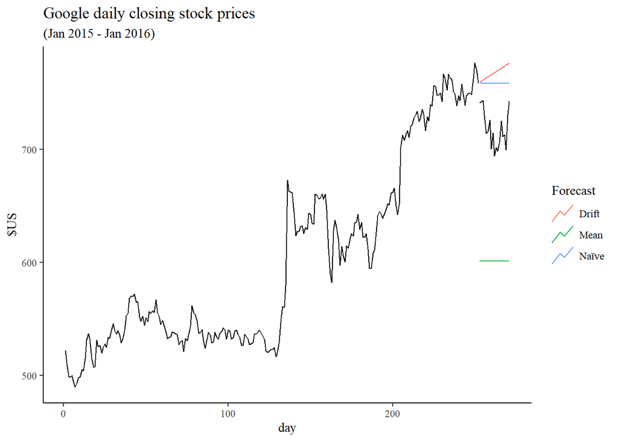

```r
# Re-index based on trading days
google_stock <- gafa_stock %>%
  filter(Symbol == "GOOG", year(Date) >= 2015) %>%
  mutate(day = row_number()) %>%
  update_tsibble(index = day, regular = TRUE)
# Filter the year of interest
google_2015 <- google_stock %>% filter(year(Date) == 2015)
# Fit the models
google_fit <- google_2015 %>%
  model(
    Mean = MEAN(Close),
    `Naïve` = NAIVE(Close),
    Drift = NAIVE(Close ~ drift())
  )
# Produce forecasts for the trading days in January 2016
google_jan_2016 <- google_stock %>%
  filter(yearmonth(Date) == yearmonth("2016 Jan"))
google_fc <- google_fit %>%
  forecast(new_data = google_jan_2016)
# Plot the forecasts
google_fc %>%
  autoplot(google_2015, level = NULL) +
  autolayer(google_jan_2016, Close, colour = "black") +
  labs(y = "$US",
       title = "Google daily closing stock prices",
       subtitle = "(Jan 2015 - Jan 2016)") +
  guides(colour = guide_legend(title = "Forecast"))
```

## Fitted values and residuals

```r
beer_fit %>% augment()
```

```
## # A tsibble: 180 x 6 [1Q]
## # Key:       .model [3]
##    .model Quarter  Beer .fitted .resid .innov
##    <chr>    <qtr> <dbl>   <dbl>  <dbl>  <dbl>
##  1 Mean   1992 Q1   443    436.   6.55   6.55
##  2 Mean   1992 Q2   410    436. -26.4  -26.4
##  3 Mean   1992 Q3   420    436. -16.4  -16.4
##  4 Mean   1992 Q4   532    436.  95.6   95.6
##  5 Mean   1993 Q1   433    436.  -3.45  -3.45
##  6 Mean   1993 Q2   421    436. -15.4  -15.4
##  7 Mean   1993 Q3   410    436. -26.4  -26.4
##  8 Mean   1993 Q4   512    436.  75.6   75.6
##  9 Mean   1994 Q1   449    436.  12.6   12.6
## 10 Mean   1994 Q2   381    436. -55.4  -55.4
## # ... with 170 more rows
```

## Residual diagnostics

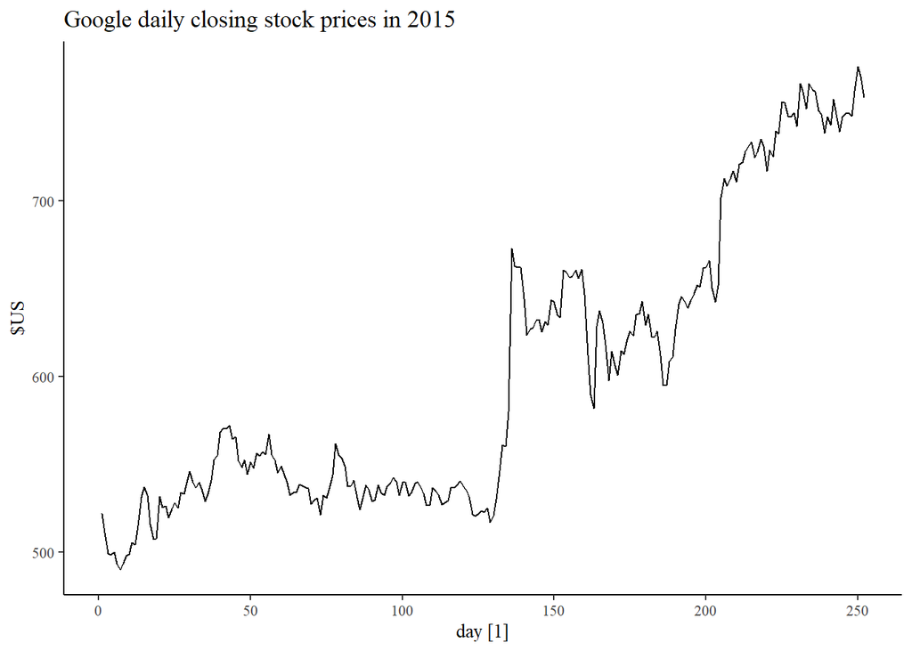

```r
autoplot(google_2015, Close) +
  labs(y = "$US",
       title = "Google daily closing stock prices in 2015")
```

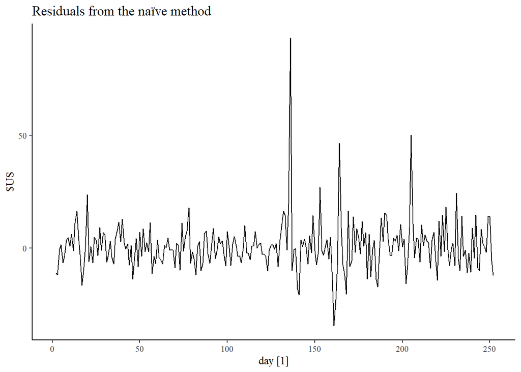

```r
aug <- google_2015 %>%
  model(NAIVE(Close)) %>%
  augment()
autoplot(aug, .innov) +
  labs(y = "$US",
       title = "Residuals from the naïve method")
```

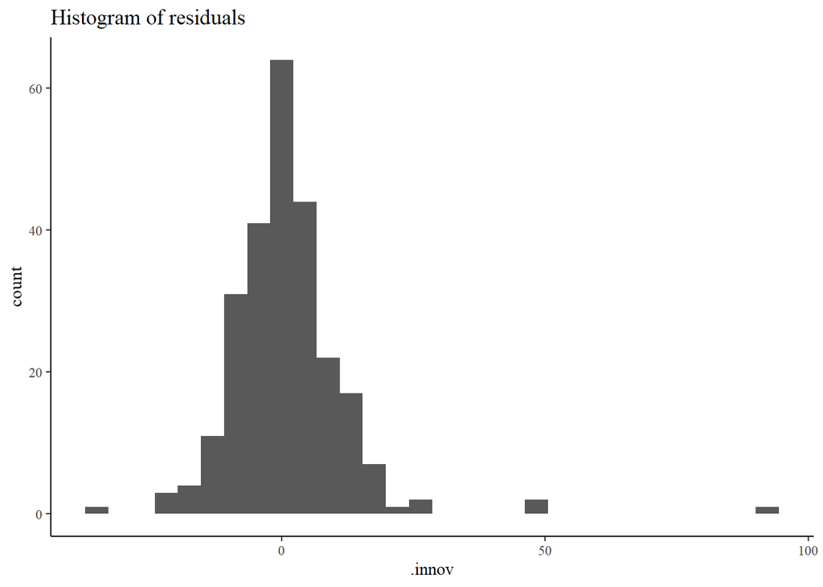

```r
aug %>%
  ggplot(aes(x = .innov)) +
  geom_histogram() +
  labs(title = "Histogram of residuals")
```

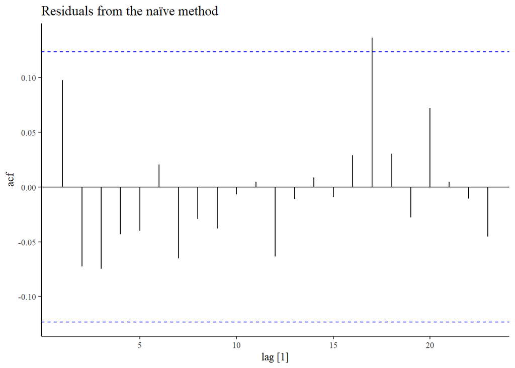

```r
aug %>%
  ACF(.innov) %>%
  autoplot() +
  labs(title = "Residuals from the naïve method")
```

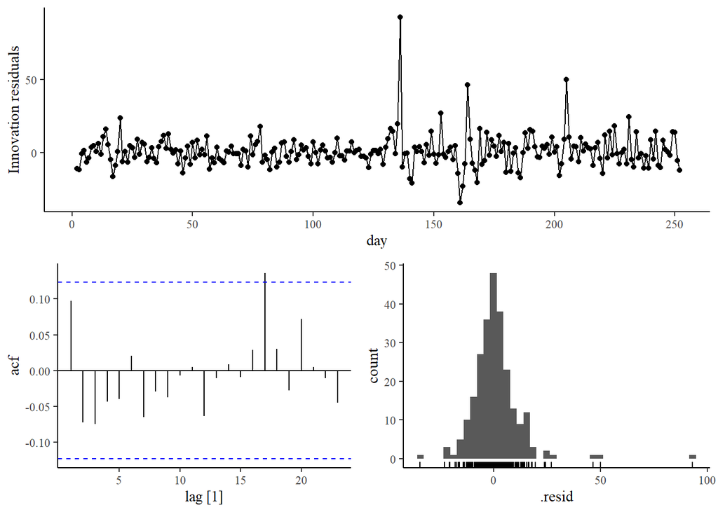

```r
google_2015 %>%
  model(NAIVE(Close)) %>%
  gg_tsresiduals()
```

```r
aug %>% features(.innov, box_pierce, lag = 10, dof = 0)
```

```
## # A tibble: 1 x 4
##   Symbol .model       bp_stat bp_pvalue
##   <chr>  <chr>          <dbl>     <dbl>
## 1 GOOG   NAIVE(Close)    7.74     0.654
```

```r
aug %>% features(.innov, ljung_box, lag = 10, dof = 0)
```

```
## # A tibble: 1 x 4
##   Symbol .model       lb_stat lb_pvalue
##   <chr>  <chr>          <dbl>     <dbl>
## 1 GOOG   NAIVE(Close)    7.91     0.637
```

```r
fit <- google_2015 %>% model(RW(Close ~ drift()))
tidy(fit)
```

```
## # A tibble: 1 x 7
##   Symbol .model              term  estimate std.error statistic p.value
##   <chr>  <chr>               <chr>    <dbl>     <dbl>     <dbl>   <dbl>
## 1 GOOG   RW(Close ~ drift()) b        0.944     0.705      1.34   0.182
```

```r
augment(fit) %>% features(.innov, ljung_box, lag=10, dof=1)
```

```
## # A tibble: 1 x 4
##   Symbol .model              lb_stat lb_pvalue
##   <chr>  <chr>                 <dbl>     <dbl>
## 1 GOOG   RW(Close ~ drift())    7.91     0.543
```

## Distributional forecasts and prediction intervals

```r
google_2015 %>%
  model(NAIVE(Close)) %>%
  forecast(h = 10) %>%
  hilo()
```

```
## # A tsibble: 10 x 7 [1]
## # Key:       Symbol, .model [1]
##    Symbol .model         day        Close .mean                  `80%`
##    <chr>  <chr>        <dbl>       <dist> <dbl>                 <hilo>
##  1 GOOG   NAIVE(Close)   253  N(759, 125)  759. [744.5400, 773.2200]80
##  2 GOOG   NAIVE(Close)   254  N(759, 250)  759. [738.6001, 779.1599]80
##  3 GOOG   NAIVE(Close)   255  N(759, 376)  759. [734.0423, 783.7177]80
##  4 GOOG   NAIVE(Close)   256  N(759, 501)  759. [730.1999, 787.5601]80
##  5 GOOG   NAIVE(Close)   257  N(759, 626)  759. [726.8147, 790.9453]80
##  6 GOOG   NAIVE(Close)   258  N(759, 751)  759. [723.7543, 794.0058]80
##  7 GOOG   NAIVE(Close)   259  N(759, 876)  759. [720.9399, 796.8202]80
##  8 GOOG   NAIVE(Close)   260 N(759, 1002)  759. [718.3203, 799.4397]80
##  9 GOOG   NAIVE(Close)   261 N(759, 1127)  759. [715.8599, 801.9001]80
## 10 GOOG   NAIVE(Close)   262 N(759, 1252)  759. [713.5329, 804.2272]80
## # ... with 1 more variable: 95% <hilo>
```

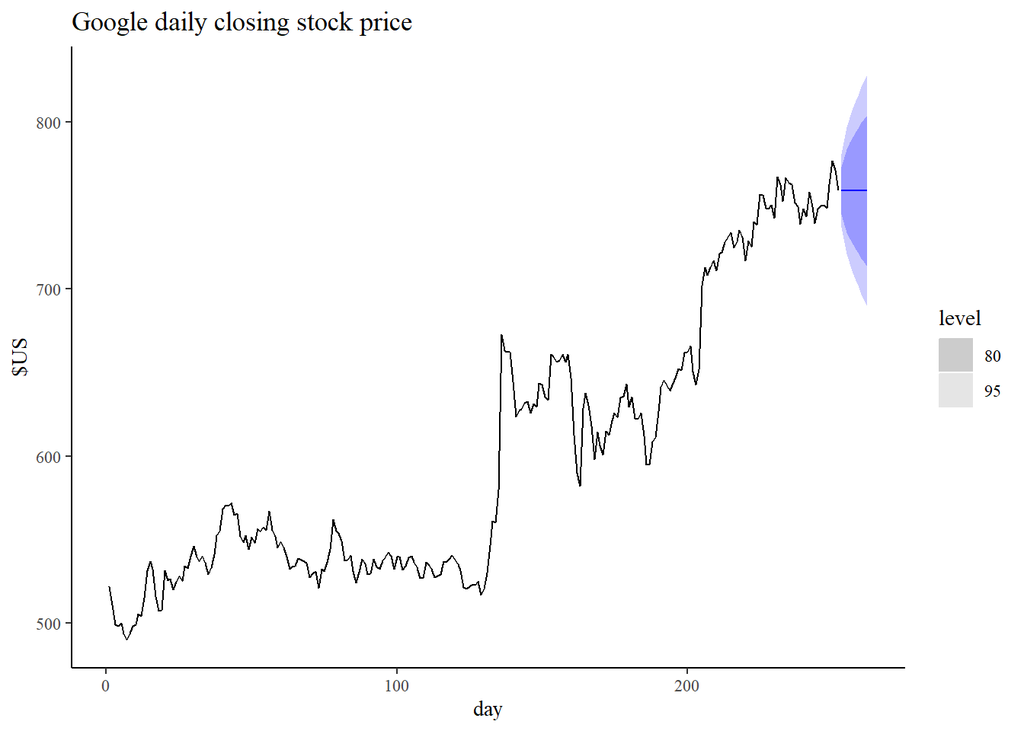

```r
google_2015 %>%
  model(NAIVE(Close)) %>%
  forecast(h = 10) %>%
  autoplot(google_2015) +
  labs(title="Google daily closing stock price", y="$US" )
```

```r
fit <- google_2015 %>%
  model(NAIVE(Close))
sim <- fit %>% generate(h = 30, times = 5, bootstrap = TRUE)
sim
```

```
## # A tsibble: 150 x 5 [1]
## # Key:       Symbol, .model, .rep [5]
##    Symbol .model         day .rep   .sim
##    <chr>  <chr>        <dbl> <chr> <dbl>
##  1 GOOG   NAIVE(Close)   253 1      741.
##  2 GOOG   NAIVE(Close)   254 1      753.
##  3 GOOG   NAIVE(Close)   255 1      770.
##  4 GOOG   NAIVE(Close)   256 1      764.
##  5 GOOG   NAIVE(Close)   257 1      768.
##  6 GOOG   NAIVE(Close)   258 1      757.
##  7 GOOG   NAIVE(Close)   259 1      760.
##  8 GOOG   NAIVE(Close)   260 1      761.
##  9 GOOG   NAIVE(Close)   261 1      749.
## 10 GOOG   NAIVE(Close)   262 1      746.
## # ... with 140 more rows
```

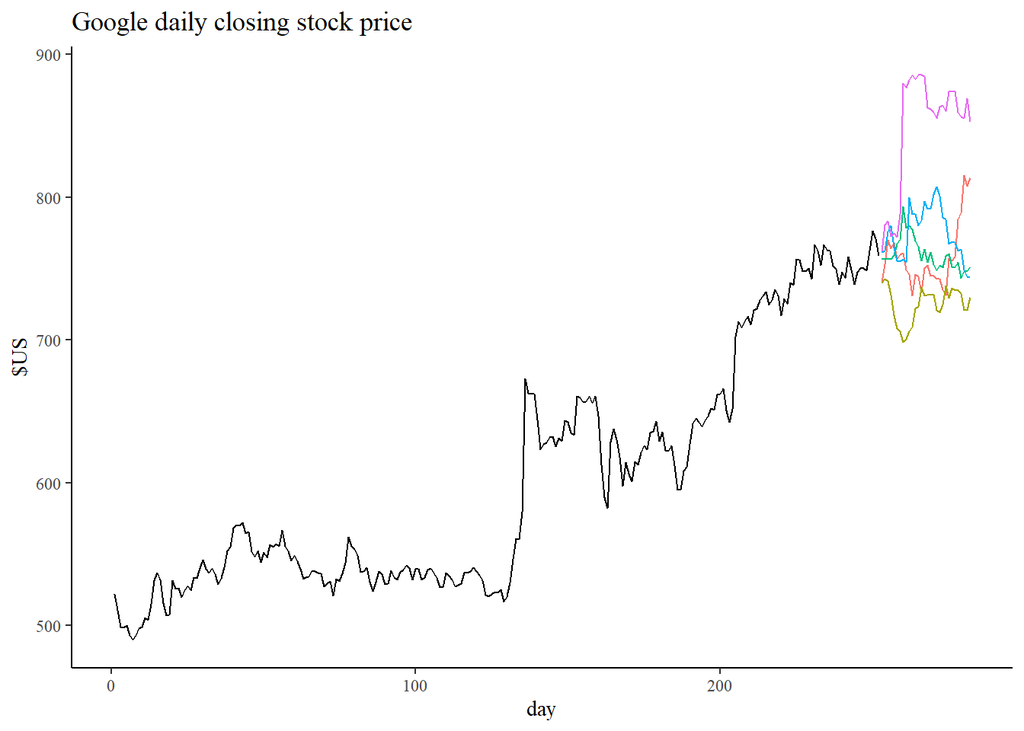

```r
google_2015 %>%
  ggplot(aes(x = day)) +
  geom_line(aes(y = Close)) +
  geom_line(aes(y = .sim, colour = as.factor(.rep)),
    data = sim) +
  labs(title="Google daily closing stock price", y="$US" ) +
  guides(colour = "none")
```

```r
fc <- fit %>% forecast(h = 30, bootstrap = TRUE)
fc
```

```
## # A fable: 30 x 5 [1]
## # Key:     Symbol, .model [1]
##    Symbol .model         day        Close .mean
##    <chr>  <chr>        <dbl>       <dist> <dbl>
##  1 GOOG   NAIVE(Close)   253 sample[5000]  759.
##  2 GOOG   NAIVE(Close)   254 sample[5000]  759.
##  3 GOOG   NAIVE(Close)   255 sample[5000]  759.
##  4 GOOG   NAIVE(Close)   256 sample[5000]  759.
##  5 GOOG   NAIVE(Close)   257 sample[5000]  759.
##  6 GOOG   NAIVE(Close)   258 sample[5000]  759.
##  7 GOOG   NAIVE(Close)   259 sample[5000]  759.
##  8 GOOG   NAIVE(Close)   260 sample[5000]  759.
##  9 GOOG   NAIVE(Close)   261 sample[5000]  759.
## 10 GOOG   NAIVE(Close)   262 sample[5000]  759.
## # ... with 20 more rows
```

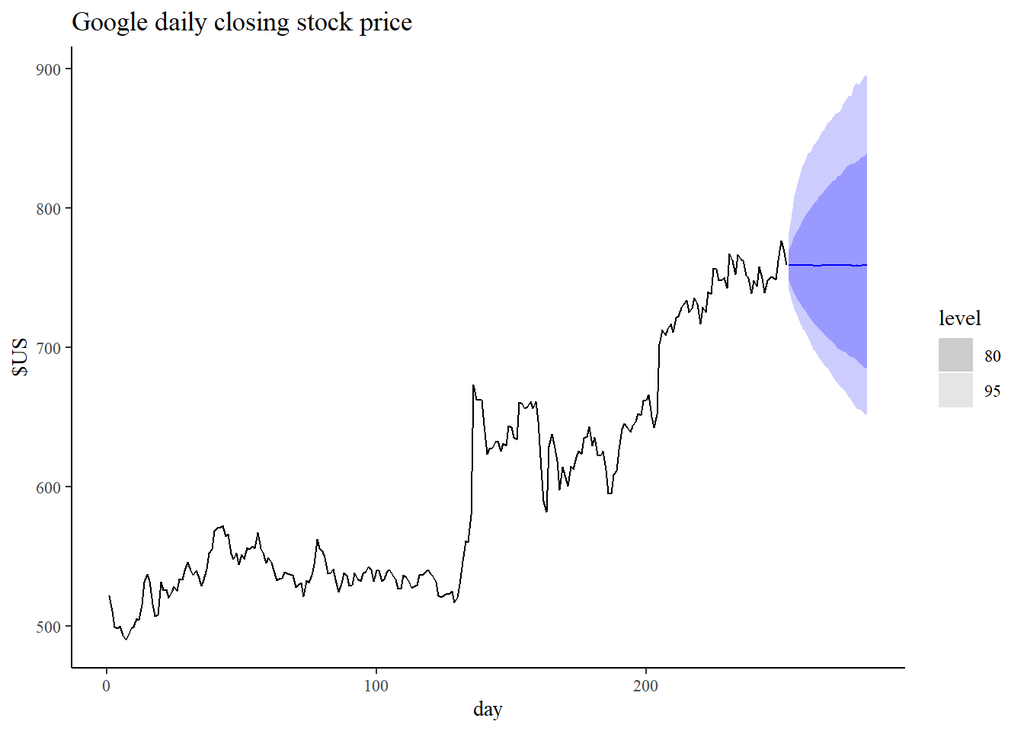

```r
autoplot(fc, google_2015) +
  labs(title="Google daily closing stock price", y="$US" )
```

```r
google_2015 %>%
  model(NAIVE(Close)) %>%
  forecast(h = 10, bootstrap = TRUE, times = 1000) %>%
  hilo()
```

```
## # A tsibble: 10 x 7 [1]
## # Key:       Symbol, .model [1]
##    Symbol .model         day        Close .mean                  `80%`
##    <chr>  <chr>        <dbl>       <dist> <dbl>                 <hilo>
##  1 GOOG   NAIVE(Close)   253 sample[1000]  759. [747.3460, 769.0150]80
##  2 GOOG   NAIVE(Close)   254 sample[1000]  759. [742.1558, 774.0341]80
##  3 GOOG   NAIVE(Close)   255 sample[1000]  759. [738.1947, 777.9868]80
##  4 GOOG   NAIVE(Close)   256 sample[1000]  760. [734.7428, 783.5961]80
##  5 GOOG   NAIVE(Close)   257 sample[1000]  759. [730.3851, 788.3211]80
##  6 GOOG   NAIVE(Close)   258 sample[1000]  759. [726.0226, 790.9968]80
##  7 GOOG   NAIVE(Close)   259 sample[1000]  759. [723.4268, 797.7312]80
##  8 GOOG   NAIVE(Close)   260 sample[1000]  759. [721.7363, 800.1555]80
##  9 GOOG   NAIVE(Close)   261 sample[1000]  759. [716.9563, 804.0706]80
## 10 GOOG   NAIVE(Close)   262 sample[1000]  759. [715.1191, 806.1743]80
## # ... with 1 more variable: 95% <hilo>
```

## Forecasting using transformations

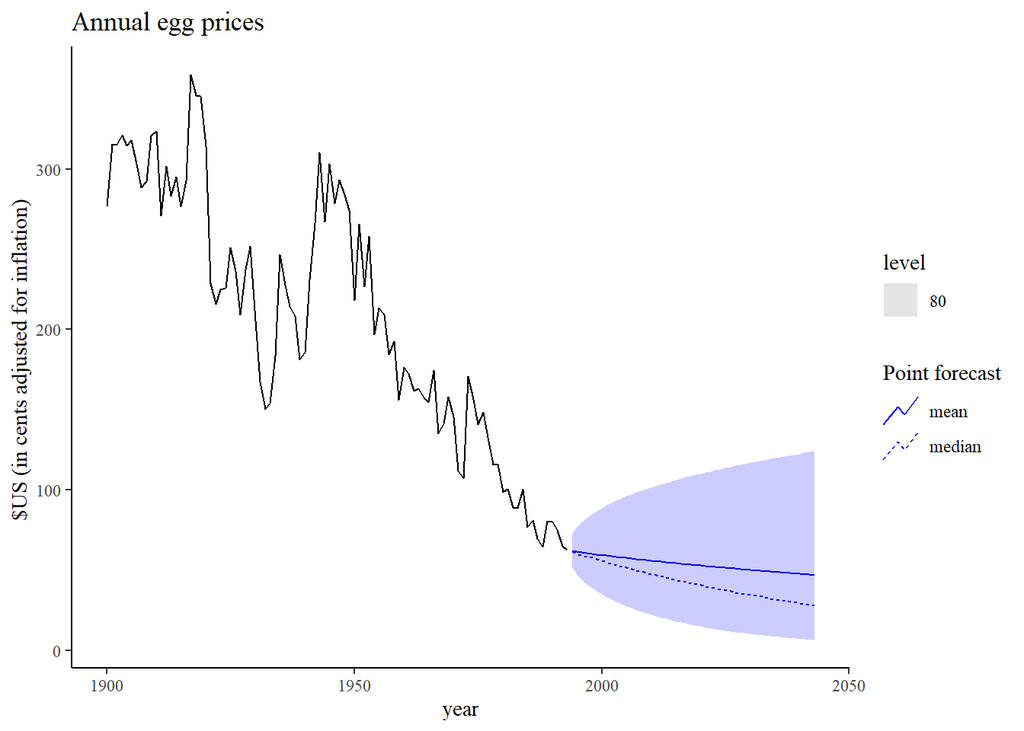

```r
prices %>%
  filter(!is.na(eggs)) %>%
  model(RW(log(eggs) ~ drift())) %>%
  forecast(h = 50) %>%
  autoplot(prices %>% filter(!is.na(eggs)),
    level = 80, point_forecast = lst(mean, median)
  ) +
  labs(title = "Annual egg prices",
       y = "$US (in cents adjusted for inflation) ")
```

## Forecasting with decomposition

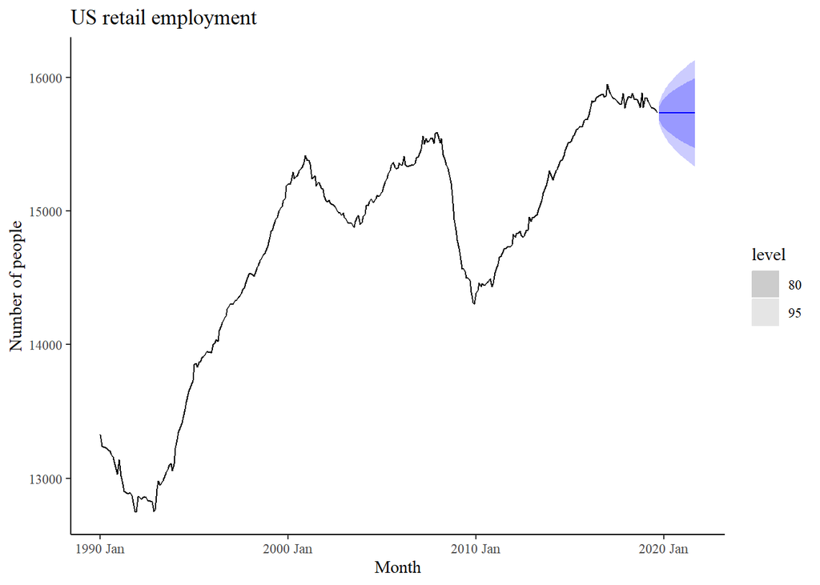

```r
us_retail_employment <- us_employment %>%
  filter(year(Month) >= 1990, Title == "Retail Trade")
dcmp <- us_retail_employment %>%
  model(STL(Employed ~ trend(window = 7), robust = TRUE)) %>%
  components() %>%
  select(-.model)
dcmp %>%
  model(NAIVE(season_adjust)) %>%
  forecast() %>%
  autoplot(dcmp) +
  labs(y = "Number of people",
       title = "US retail employment")
```

Reminder: this is the adjusted trend (i.e. no seasonality). This is why the graph is different from the one below.

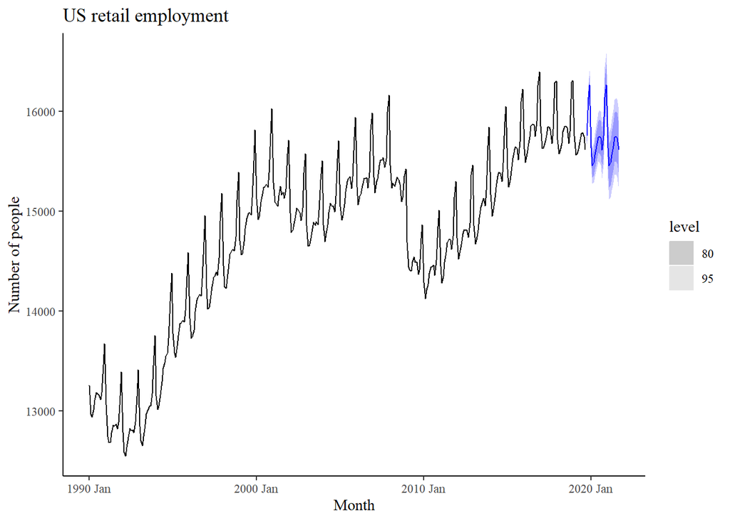

```r
fit_dcmp <- us_retail_employment %>%
  model(stlf = decomposition_model(
    STL(Employed ~ trend(window = 7), robust = TRUE),
    NAIVE(season_adjust)
  ))
fit_dcmp %>%
  forecast() %>%
  autoplot(us_retail_employment)+
  labs(y = "Number of people",
       title = "US retail employment")
```

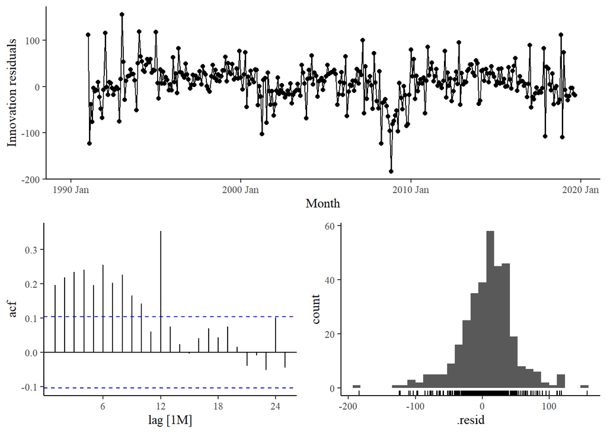

```r
fit_dcmp %>% gg_tsresiduals()
```

## Evaluating point forecast accuracy

```r
aus_production %>% filter(year(Quarter) >= 1995)
```

```
## # A tsibble: 62 x 7 [1Q]
##    Quarter  Beer Tobacco Bricks Cement Electricity   Gas
##      <qtr> <dbl>   <dbl>  <dbl>  <dbl>       <dbl> <dbl>
##  1 1995 Q1   426    4714    430   1626       41768   131
##  2 1995 Q2   408    3939    457   1703       43686   167
##  3 1995 Q3   416    6137    417   1733       46022   181
##  4 1995 Q4   520    4739    370   1545       42800   145
##  5 1996 Q1   409    4275    310   1526       43661   133
##  6 1996 Q2   398    5239    358   1593       44707   162
##  7 1996 Q3   398    6293    379   1706       46326   184
##  8 1996 Q4   507    5575    369   1699       43346   146
##  9 1997 Q1   432    4802    330   1511       43938   135
## 10 1997 Q2   398    5523    390   1785       45828   171
## # ... with 52 more rows
```

```r
aus_production %>% filter_index("1995 Q1" ~ .)
```

```
## # A tsibble: 62 x 7 [1Q]
##    Quarter  Beer Tobacco Bricks Cement Electricity   Gas
##      <qtr> <dbl>   <dbl>  <dbl>  <dbl>       <dbl> <dbl>
##  1 1995 Q1   426    4714    430   1626       41768   131
##  2 1995 Q2   408    3939    457   1703       43686   167
##  3 1995 Q3   416    6137    417   1733       46022   181
##  4 1995 Q4   520    4739    370   1545       42800   145
##  5 1996 Q1   409    4275    310   1526       43661   133
##  6 1996 Q2   398    5239    358   1593       44707   162
##  7 1996 Q3   398    6293    379   1706       46326   184
##  8 1996 Q4   507    5575    369   1699       43346   146
##  9 1997 Q1   432    4802    330   1511       43938   135
## 10 1997 Q2   398    5523    390   1785       45828   171
## # ... with 52 more rows
```

```r
aus_production %>%
  slice(n()-19:0)
```

```
## # A tsibble: 20 x 7 [1Q]
##    Quarter  Beer Tobacco Bricks Cement Electricity   Gas
##      <qtr> <dbl>   <dbl>  <dbl>  <dbl>       <dbl> <dbl>
##  1 2005 Q3   408      NA     NA   2340       56043   221
##  2 2005 Q4   482      NA     NA   2265       54992   180
##  3 2006 Q1   438      NA     NA   2027       57112   171
##  4 2006 Q2   386      NA     NA   2278       57157   224
##  5 2006 Q3   405      NA     NA   2427       58400   233
##  6 2006 Q4   491      NA     NA   2451       56249   192
##  7 2007 Q1   427      NA     NA   2140       56244   187
##  8 2007 Q2   383      NA     NA   2362       55036   234
##  9 2007 Q3   394      NA     NA   2536       59806   245
## 10 2007 Q4   473      NA     NA   2562       56411   205
## 11 2008 Q1   420      NA     NA   2183       59118   194
## 12 2008 Q2   390      NA     NA   2558       56660   229
## 13 2008 Q3   410      NA     NA   2612       64067   249
## 14 2008 Q4   488      NA     NA   2373       59045   203
## 15 2009 Q1   415      NA     NA   1963       58368   196
## 16 2009 Q2   398      NA     NA   2160       57471   238
## 17 2009 Q3   419      NA     NA   2325       58394   252
## 18 2009 Q4   488      NA     NA   2273       57336   210
## 19 2010 Q1   414      NA     NA   1904       58309   205
## 20 2010 Q2   374      NA     NA   2401       58041   236
```

```r
aus_retail %>%
  group_by(State, Industry) %>%
  slice(1:12)
```

```
## # A tsibble: 1,824 x 5 [1M]
## # Key:       State, Industry [152]
## # Groups:    State, Industry [152]
##    State                        Industry           `Series ID`    Month Turnover
##    <chr>                        <chr>              <chr>          <mth>    <dbl>
##  1 Australian Capital Territory Cafes, restaurant~ A3349849A   1982 Apr      4.4
##  2 Australian Capital Territory Cafes, restaurant~ A3349849A   1982 May      3.4
##  3 Australian Capital Territory Cafes, restaurant~ A3349849A   1982 Jun      3.6
##  4 Australian Capital Territory Cafes, restaurant~ A3349849A   1982 Jul      4
##  5 Australian Capital Territory Cafes, restaurant~ A3349849A   1982 Aug      3.6
##  6 Australian Capital Territory Cafes, restaurant~ A3349849A   1982 Sep      4.2
##  7 Australian Capital Territory Cafes, restaurant~ A3349849A   1982 Oct      4.8
##  8 Australian Capital Territory Cafes, restaurant~ A3349849A   1982 Nov      5.4
##  9 Australian Capital Territory Cafes, restaurant~ A3349849A   1982 Dec      6.9
## 10 Australian Capital Territory Cafes, restaurant~ A3349849A   1983 Jan      3.8
## # ... with 1,814 more rows
```

Very nice, if you need the n first observations by group. (Or you could also just use filter() now that I think about it.)

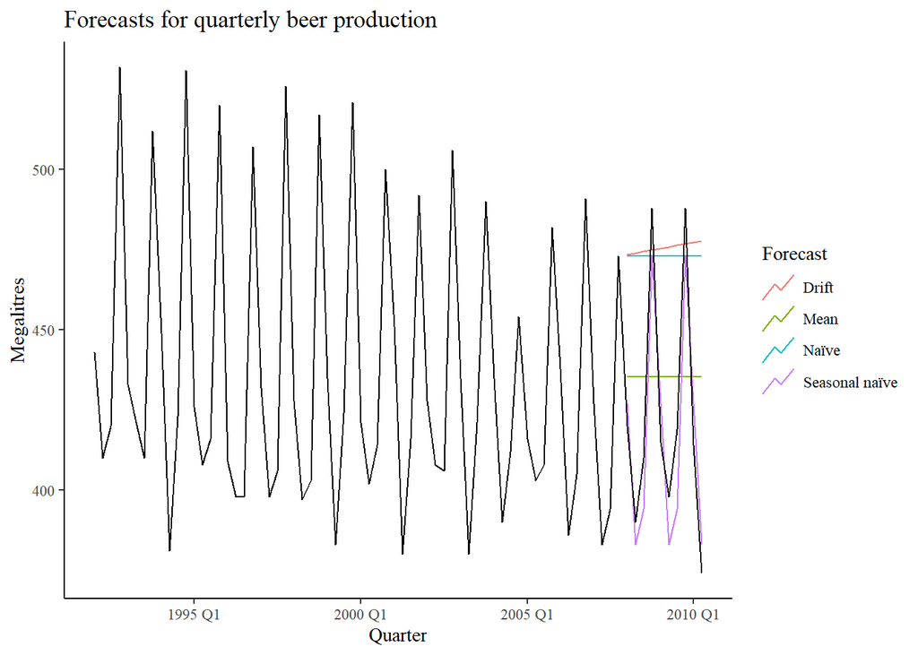

```r
recent_production <- aus_production %>%
  filter(year(Quarter) >= 1992)
beer_train <- recent_production %>%
  filter(year(Quarter) <= 2007)

beer_fit <- beer_train %>%
  model(
    Mean = MEAN(Beer),
    `Naïve` = NAIVE(Beer),
    `Seasonal naïve` = SNAIVE(Beer),
    Drift = RW(Beer ~ drift())
  )

beer_fc <- beer_fit %>%
  forecast(h = 10)

beer_fc %>%
  autoplot(
    aus_production %>% filter(year(Quarter) >= 1992),
    level = NULL
  ) +
  labs(
    y = "Megalitres",
    title = "Forecasts for quarterly beer production"
  ) +
  guides(colour = guide_legend(title = "Forecast"))
```

```r
accuracy(beer_fc, recent_production)
```

```
## # A tibble: 4 x 10
##   .model         .type    ME  RMSE   MAE    MPE  MAPE  MASE RMSSE    ACF1
##   <chr>          <chr> <dbl> <dbl> <dbl>  <dbl> <dbl> <dbl> <dbl>   <dbl>
## 1 Drift          Test  -54.0  64.9  58.9 -13.6  14.6  4.12  3.87  -0.0741
## 2 Mean           Test  -13.8  38.4  34.8  -3.97  8.28 2.44  2.29  -0.0691
## 3 Naïve          Test  -51.4  62.7  57.4 -13.0  14.2  4.01  3.74  -0.0691
## 4 Seasonal naïve Test    5.2  14.3  13.4   1.15  3.17 0.937 0.853  0.132
```

```r
google_fit <- google_2015 %>%
  model(
    Mean = MEAN(Close),
    `Naïve` = NAIVE(Close),
    Drift = RW(Close ~ drift())
  )

google_fc <- google_fit %>%
  forecast(google_jan_2016)
```

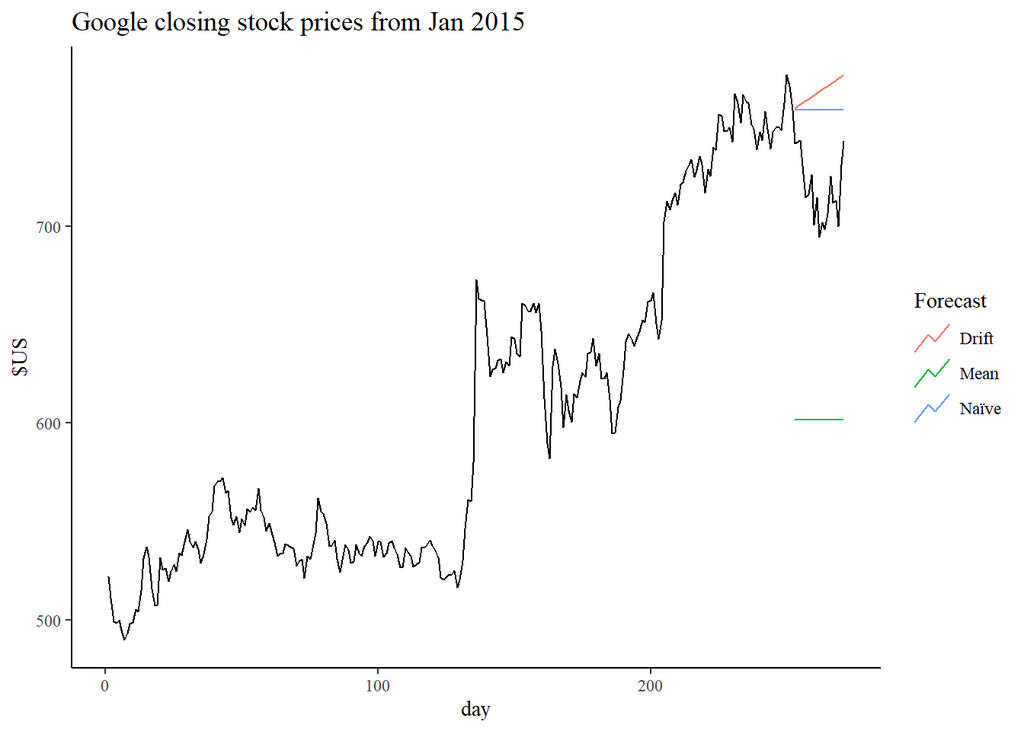

```r
google_fc %>%
  autoplot(bind_rows(google_2015, google_jan_2016),
    level = NULL) +
  labs(y = "$US",
       title = "Google closing stock prices from Jan 2015") +
  guides(colour = guide_legend(title = "Forecast"))
```

## Evaluating distributional forecast accuracy

```r
google_fit %>%
  forecast(google_jan_2016
  ) %>%
  hilo(level = c(80, 95)) %>%
  print(n = 100)
```

```
## # A tsibble: 57 x 13 [1]
## # Key:       Symbol, .model [3]
##    Symbol .model   day        Close .mean Date        Open  High   Low Adj_Close
##    <chr>  <chr>  <int>       <dist> <dbl> <date>     <dbl> <dbl> <dbl>     <dbl>
##  1 GOOG   Mean     253 N(602, 6766)  602. 2016-01-04  743   744.  731.      742.
##  2 GOOG   Mean     254 N(602, 6766)  602. 2016-01-05  746.  752   739.      743.
##  3 GOOG   Mean     255 N(602, 6766)  602. 2016-01-06  730   747.  729.      744.
##  4 GOOG   Mean     256 N(602, 6766)  602. 2016-01-07  730.  738.  719.      726.
##  5 GOOG   Mean     257 N(602, 6766)  602. 2016-01-08  731.  733.  713       714.
##  6 GOOG   Mean     258 N(602, 6766)  602. 2016-01-11  717.  719.  704.      716.
##  7 GOOG   Mean     259 N(602, 6766)  602. 2016-01-12  722.  729.  717.      726.
##  8 GOOG   Mean     260 N(602, 6766)  602. 2016-01-13  731.  735.  699.      701.
##  9 GOOG   Mean     261 N(602, 6766)  602. 2016-01-14  705.  722.  689.      715.
## 10 GOOG   Mean     262 N(602, 6766)  602. 2016-01-15  692.  707.  685.      694.
## 11 GOOG   Mean     263 N(602, 6766)  602. 2016-01-19  703.  710.  693.      702.
```

[output cut: 47 more lines]

hilo() to get confidence intervals. It may be written above, but I had forgotten it at that moment.

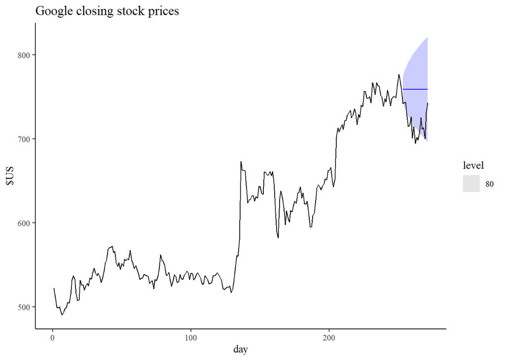

```r
google_fc %>%
  filter(.model == "Naïve") %>%
  autoplot(bind_rows(google_2015, google_jan_2016), level=80)+
  labs(y = "$US",
       title = "Google closing stock prices")
```

```r
google_fc %>%
  filter(.model == "Naïve", Date == "2016-01-04") %>%
  accuracy(google_stock, list(qs=quantile_score), probs=0.10)
```

```
## # A tibble: 1 x 4
##   .model Symbol .type    qs
##   <chr>  <chr>  <chr> <dbl>
## 1 Naïve  GOOG   Test   4.86
```

```r
google_stock %>% filter(Date == "2016-01-04") %>% view()
```

```r
google_fc %>%
  filter(.model == "Naïve", Date == "2016-01-04") %>%
  accuracy(google_stock,
    list(winkler = winkler_score), level = 80)
```

```
## # A tibble: 1 x 4
##   .model Symbol .type winkler
##   <chr>  <chr>  <chr>   <dbl>
## 1 Naïve  GOOG   Test     55.7
```

```r
google_fc %>%
  accuracy(google_stock, list(crps = CRPS))
```

```
## # A tibble: 3 x 4
##   .model Symbol .type  crps
##   <chr>  <chr>  <chr> <dbl>
## 1 Drift  GOOG   Test   33.5
## 2 Mean   GOOG   Test   76.7
## 3 Naïve  GOOG   Test   26.5
```

```r
google_fc %>%
  accuracy(google_stock, list(skill = skill_score(CRPS)))
```

```
## # A tibble: 3 x 4
##   .model Symbol .type  skill
##   <chr>  <chr>  <chr>  <dbl>
## 1 Drift  GOOG   Test  -0.266
## 2 Mean   GOOG   Test  -1.90
## 3 Naïve  GOOG   Test   0
```

## Time-series cross-validation

```r
# Time series cross-validation accuracy
google_2015_tr <- google_2015 %>%
  stretch_tsibble(.init = 3, .step = 1) %>%
  relocate(Date, Symbol, .id)
google_2015_tr
```

```
## # A tsibble: 31,875 x 10 [1]
## # Key:       Symbol, .id [250]
##    Date       Symbol   .id  Open  High   Low Close Adj_Close  Volume   day
##    <date>     <chr>  <int> <dbl> <dbl> <dbl> <dbl>     <dbl>   <dbl> <int>
##  1 2015-01-02 GOOG       1  526.  528.  521.  522.      522. 1447600     1
##  2 2015-01-05 GOOG       1  520.  521.  510.  511.      511. 2059800     2
##  3 2015-01-06 GOOG       1  512.  513.  498.  499.      499. 2899900     3
##  4 2015-01-02 GOOG       2  526.  528.  521.  522.      522. 1447600     1
##  5 2015-01-05 GOOG       2  520.  521.  510.  511.      511. 2059800     2
##  6 2015-01-06 GOOG       2  512.  513.  498.  499.      499. 2899900     3
##  7 2015-01-07 GOOG       2  504.  504.  497.  498.      498. 2065100     4
##  8 2015-01-02 GOOG       3  526.  528.  521.  522.      522. 1447600     1
##  9 2015-01-05 GOOG       3  520.  521.  510.  511.      511. 2059800     2
## 10 2015-01-06 GOOG       3  512.  513.  498.  499.      499. 2899900     3
## # ... with 31,865 more rows
```

```r
# TSCV accuracy
google_2015_tr %>%
  model(RW(Close ~ drift())) %>%
  forecast(h = 1) %>%
  accuracy(google_2015)
```

```
## # A tibble: 1 x 11
##   .model           Symbol .type    ME  RMSE   MAE   MPE  MAPE  MASE RMSSE   ACF1
##   <chr>            <chr>  <chr> <dbl> <dbl> <dbl> <dbl> <dbl> <dbl> <dbl>  <dbl>
## 1 RW(Close ~ drif~ GOOG   Test  0.726  11.3  7.26 0.112  1.19  1.02  1.01 0.0985
```

```r
# Training set accuracy
google_2015 %>%
  model(RW(Close ~ drift())) %>%
  accuracy()
```

```
## # A tibble: 1 x 11
##   Symbol .model     .type        ME  RMSE   MAE     MPE  MAPE  MASE RMSSE   ACF1
##   <chr>  <chr>      <chr>     <dbl> <dbl> <dbl>   <dbl> <dbl> <dbl> <dbl>  <dbl>
## 1 GOOG   RW(Close ~ Trai~ -2.97e-14  11.1  7.16 -0.0267  1.18  1.00 0.996 0.0976
```

```r
google_2015_tr <- google_2015 %>%
  stretch_tsibble(.init = 3, .step = 1)
fc <- google_2015_tr %>%
  model(RW(Close ~ drift())) %>%
  forecast(h = 8)
```

```r
fc %>% print(n = 50)
```

```
## # A fable: 2,000 x 6 [1]
## # Key:     .id, Symbol, .model [250]
##      .id Symbol .model                day        Close .mean
##    <int> <chr>  <chr>               <dbl>       <dist> <dbl>
##  1     1 GOOG   RW(Close ~ drift())     4 N(488, 0.47)  488.
##  2     1 GOOG   RW(Close ~ drift())     5  N(476, 1.4)  476.
##  3     1 GOOG   RW(Close ~ drift())     6  N(465, 2.8)  465.
##  4     1 GOOG   RW(Close ~ drift())     7  N(454, 4.7)  454.
##  5     1 GOOG   RW(Close ~ drift())     8    N(442, 7)  442.
##  6     1 GOOG   RW(Close ~ drift())     9  N(431, 9.8)  431.
##  7     1 GOOG   RW(Close ~ drift())    10   N(420, 13)  420.
##  8     1 GOOG   RW(Close ~ drift())    11   N(408, 17)  408.
##  9     2 GOOG   RW(Close ~ drift())     5   N(490, 37)  490.
## 10     2 GOOG   RW(Close ~ drift())     6   N(483, 99)  483.
## 11     2 GOOG   RW(Close ~ drift())     7  N(475, 185)  475.
```

[output cut: 40 more lines]

.id == 1: forecasts for day 4 to 11 (8 days) using the first three days .id == 2: forecasts for day 5 to 12 (8 days) using the first four days

And so on.

```r
google_2015_tr <- google_2015 %>%
  stretch_tsibble(.init = 3, .step = 1)
fc <- google_2015_tr %>%
  model(RW(Close ~ drift())) %>%
  forecast(h = 8) %>%
  group_by(.id) %>%
  mutate(h = row_number()) %>%
  ungroup()

# fc dataset
fc %>% print(n = 50)
```

```
## # A fable: 2,000 x 7 [1]
## # Key:     .id, Symbol, .model [250]
##      .id Symbol .model                day        Close .mean     h
##    <int> <chr>  <chr>               <dbl>       <dist> <dbl> <int>
##  1     1 GOOG   RW(Close ~ drift())     4 N(488, 0.47)  488.     1
##  2     1 GOOG   RW(Close ~ drift())     5  N(476, 1.4)  476.     2
##  3     1 GOOG   RW(Close ~ drift())     6  N(465, 2.8)  465.     3
##  4     1 GOOG   RW(Close ~ drift())     7  N(454, 4.7)  454.     4
##  5     1 GOOG   RW(Close ~ drift())     8    N(442, 7)  442.     5
##  6     1 GOOG   RW(Close ~ drift())     9  N(431, 9.8)  431.     6
##  7     1 GOOG   RW(Close ~ drift())    10   N(420, 13)  420.     7
##  8     1 GOOG   RW(Close ~ drift())    11   N(408, 17)  408.     8
##  9     2 GOOG   RW(Close ~ drift())     5   N(490, 37)  490.     1
## 10     2 GOOG   RW(Close ~ drift())     6   N(483, 99)  483.     2
## 11     2 GOOG   RW(Close ~ drift())     7  N(475, 185)  475.     3
```

[output cut: 40 more lines]

```r
# Accuracy
fc %>%
  accuracy(google_2015, by = c("h", ".model"))
```

```
## # A tibble: 8 x 11
##       h .model            .type    ME  RMSE   MAE   MPE  MAPE  MASE RMSSE   ACF1
##   <int> <chr>             <chr> <dbl> <dbl> <dbl> <dbl> <dbl> <dbl> <dbl>  <dbl>
## 1     1 RW(Close ~ drift~ Test  0.726  11.3  7.26 0.112  1.19  1.02  1.01 0.0985
## 2     2 RW(Close ~ drift~ Test  1.52   16.9 11.0  0.228  1.82  1.54  1.51 0.509
## 3     3 RW(Close ~ drift~ Test  2.34   20.7 14.0  0.350  2.32  1.96  1.85 0.668
## 4     4 RW(Close ~ drift~ Test  3.15   23.7 16.0  0.474  2.65  2.24  2.12 0.749
## 5     5 RW(Close ~ drift~ Test  3.93   26.4 17.7  0.596  2.94  2.48  2.36 0.791
## 6     6 RW(Close ~ drift~ Test  4.71   28.7 19.3  0.718  3.21  2.71  2.57 0.827
## 7     7 RW(Close ~ drift~ Test  5.49   31.2 21.3  0.837  3.53  2.99  2.79 0.833
## 8     8 RW(Close ~ drift~ Test  6.27   33.3 22.6  0.958  3.75  3.17  2.98 0.848
```

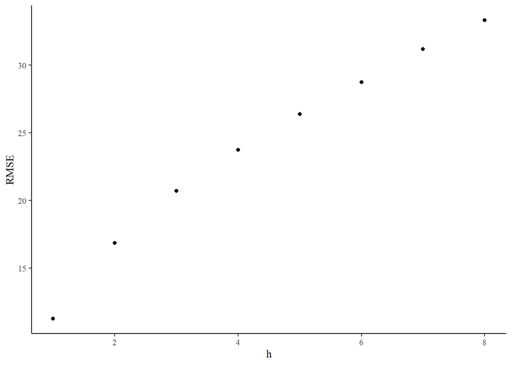

```r
fc %>%
  accuracy(google_2015, by = c("h", ".model")) %>%
  ggplot(aes(x = h, y = RMSE)) +
  geom_point()
```

## Exercises

1. Produce forecasts using NAIVE, SNAIVE or drift()

**Australian population**

```r
global_economy_aus <- global_economy %>% filter(Country ==  "Australia")
global_economy_aus
```

```
## # A tsibble: 58 x 9 [1Y]
## # Key:       Country [1]
##    Country   Code   Year          GDP Growth   CPI Imports Exports Population
##    <fct>     <fct> <dbl>        <dbl>  <dbl> <dbl>   <dbl>   <dbl>      <dbl>
##  1 Australia AUS    1960 18573188487.  NA     7.96    14.1    13.0   10276477
##  2 Australia AUS    1961 19648336880.   2.49  8.14    15.0    12.4   10483000
##  3 Australia AUS    1962 19888005376.   1.30  8.12    12.6    13.9   10742000
##  4 Australia AUS    1963 21501847911.   6.21  8.17    13.8    13.0   10950000
##  5 Australia AUS    1964 23758539590.   6.98  8.40    13.8    14.9   11167000
##  6 Australia AUS    1965 25931235301.   5.98  8.69    15.3    13.2   11388000
##  7 Australia AUS    1966 27261731437.   2.38  8.98    15.1    12.9   11651000
##  8 Australia AUS    1967 30389741292.   6.30  9.29    13.9    12.9   11799000
##  9 Australia AUS    1968 32657632434.   5.10  9.52    14.5    12.3   12009000
## 10 Australia AUS    1969 36620002240.   7.04  9.83    13.3    12.0   12263000
## # ... with 48 more rows
```

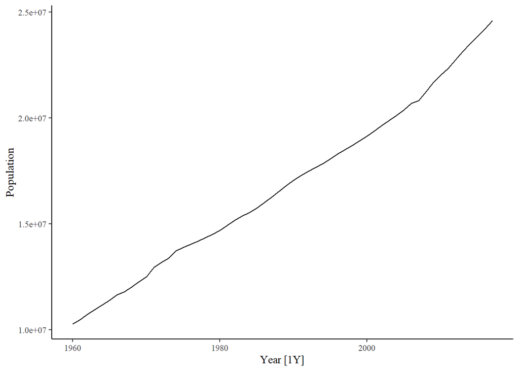

```r
global_economy_aus %>% autoplot(Population)
```

Drift is probably better.

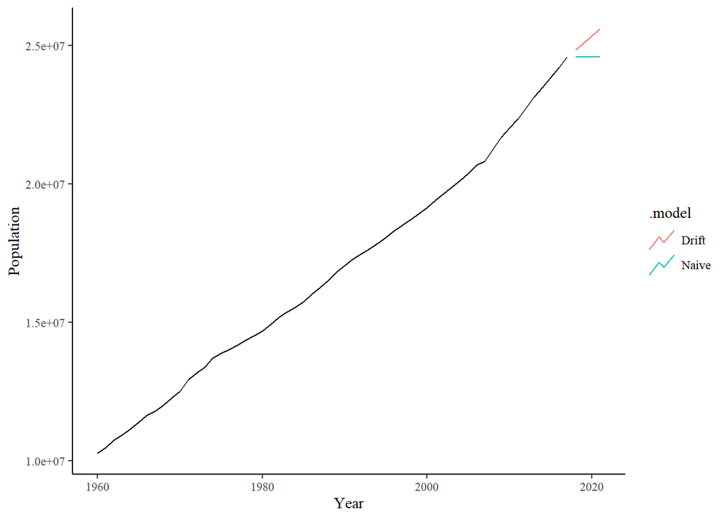

```r
global_economy_aus %>%
  model(
    Naive = NAIVE(Population),
    Drift = RW(Population ~ drift())
  ) %>%
  forecast(h = 4) %>%
  autoplot(global_economy_aus, level = NULL)
```

SNAIVE didn’t work, I don’t know why?

Using forecast() only yields the h periods after the last year in the dataset. The original dataset is put in autoplot, so the original time series is also in the graph.

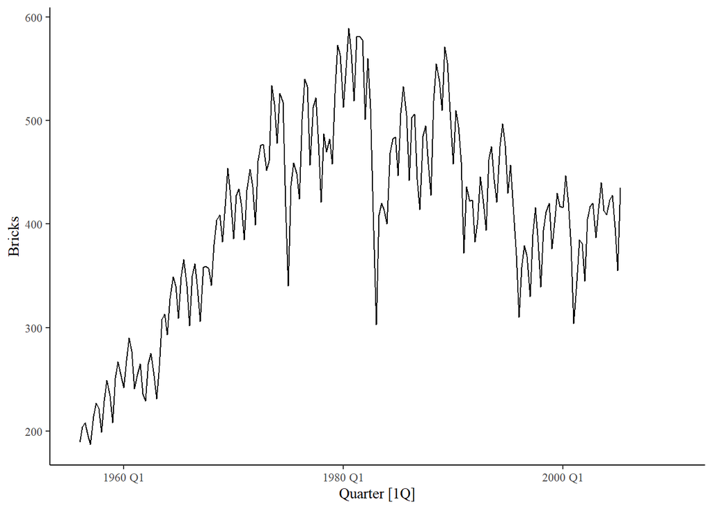

```r
aus_production %>% autoplot(Bricks)
```

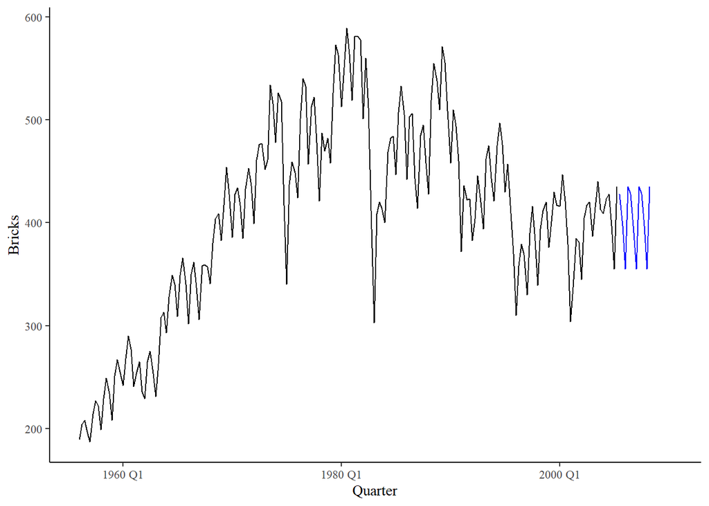

```r
aus_production %>%
  drop_na(Bricks) %>%
  model(SNAIVE = SNAIVE(Bricks ~ lag("year"))) %>%
  forecast(h = 12) %>%
  autoplot(aus_production, level = NULL)
```

There are NAs in the Bricks column. You can change the seasonality in SNAIVE (e.g. “year”, “2 year”, “3 year”)

```r
aus_livestock %>% tabyl(Animal) %>%
  adorn_pct_formatting(2) %>%
  kable()
```

| Animal | n | percent |
| --- | --- | --- |
| Bulls, bullocks and steers | 4056 | 13.81% |
| Calves | 4464 | 15.20% |
| Cattle (excl. calves) | 4464 | 15.20% |
| Cows and heifers | 3546 | 12.08% |
| Lambs | 3906 | 13.30% |
| Pigs | 4464 | 15.20% |
| Sheep | 4464 | 15.20% |

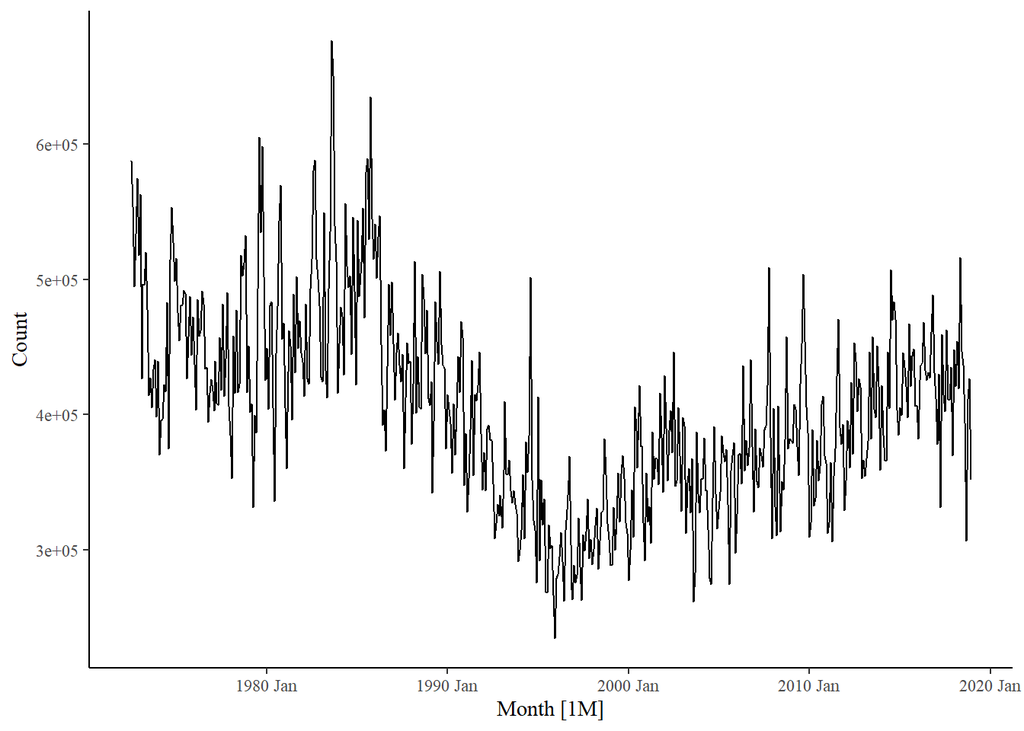

```r
aus_livestock %>%
  filter(Animal == "Lambs" & State == "New South Wales") %>%
  autoplot(Count)
```

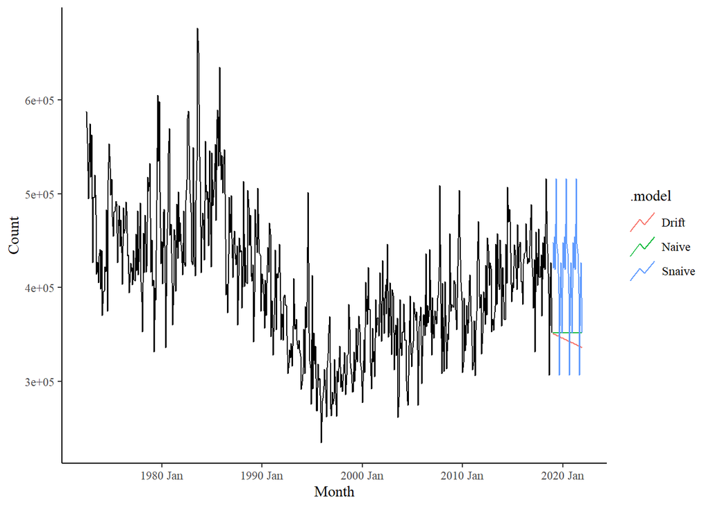

```r
aus_livestock %>%
  filter(Animal == "Lambs" & State == "New South Wales") %>%
  model(
    Naive = NAIVE(Count),
    Snaive = SNAIVE(Count),
    Drift = RW(Count ~ drift())
  ) %>%
  forecast(h = "3 year") %>%
  autoplot(aus_livestock, level = NULL)
```

No point in doing anything other than Seasonal Naive.

I’ll stop there for this exercise, I’ve done enough.